# SQL Homework Assignment

Author

Rachel Stagner

Published

October 18, 2026

# Part 1 - SQL Code Run through RStudio

Load packages, download the `flights.duckdb` file, and create the connection to the database with `duckdb`.

```r
library(tidyverse)
library(DBI)
library(duckdb)

# Download the DuckDB file from the provided URL
url <- "https://data-science-master.github.io/lectures/data/flights.duckdb"

download.file(url, destfile = "flights.duckdb", mode = "wb")

#create the connection and help translate between R and the database
conn <- dbConnect(duckdb(), "flights.duckdb", read_only = TRUE)

dbIsValid(conn) #check the connection
```

```
[1] TRUE
```

*Note: I completed all section of Part 1 in an R file, first, before creating this qmd file. Thus, my first five git commits will reflect changes in the .R file for each section. Then, between completing parts 1 and 2, I created the qmd file, added the commentary and code chunks for part 1, and inserted the screen shots for Part 2.*

## Part 1a - List the first 10 rows of the flights table.

I was uncertain if I was supposed to use R commands and have them translated into SQL, but since the directions said to run SQL using RStudio, I used the following code structure for all of my solutions. It uses the `DBI` command `dbGetQuery()` to run the SQL code through the `duckdb` connection defined above (`conn`).

```r
#Part 1a - List the first 10 rows of the flights table
dbGetQuery(conn,
           "SELECT * --get all columns
           FROM flights --from the flights table
           LIMIT 10 --first 10 rows"
)
```

```
   year month day dep_time sched_dep_time dep_delay arr_time sched_arr_time
1  2013     1   1      517            515         2      830            819
2  2013     1   1      533            529         4      850            830
3  2013     1   1      542            540         2      923            850
4  2013     1   1      544            545        -1     1004           1022
5  2013     1   1      554            600        -6      812            837
6  2013     1   1      554            558        -4      740            728
7  2013     1   1      555            600        -5      913            854
8  2013     1   1      557            600        -3      709            723
9  2013     1   1      557            600        -3      838            846
10 2013     1   1      558            600        -2      753            745
   arr_delay carrier flight tailnum origin dest air_time distance hour minute
1         11      UA   1545  N14228    EWR  IAH      227     1400    5     15
2         20      UA   1714  N24211    LGA  IAH      227     1416    5     29
3         33      AA   1141  N619AA    JFK  MIA      160     1089    5     40
```

[output cut: 18 more lines]

## Part 1b - Find the number of flights in the `flights` table, then by each carrier

I wasn’t sure if I was supposed to combine these into one SQL command, or have them be separate (i.e., find total number of flights with one command, then group them by `carrier` with another). I chose to do them separately with the following code chunks:

First, find the total number of flights using the `COUNT` command.

```r
#Part 1b - first, find the number of flights in the dataset

count_flights <- "SELECT COUNT(*) --counts the number of rows
                  FROM flights --in the flights table"

dbGetQuery(conn, count_flights) #returns the result
```

```
  count_star()
1       336776
```

Second, select the `carrier` column in the `flights` table, count the number of flights and store in a new column `n_flights` and group by carrier.

```r
#Part 1b - second find the number of flights by carrier

carrier_flights <- "SELECT carrier, --select the carrier column
                    COUNT(*) AS n_flights --count the number of rows
                    FROM flights --in the flights table
                    GROUP BY carrier --grouped by carrier"

dbGetQuery(conn, carrier_flights) #returns the result
```

```
   carrier n_flights
1       FL      3260
2       HA       342
3       OO        32
4       UA     58665
5       MQ     26397
6       VX      5162
7       AA     32729
8       EV     54173
9       US     20536
10      9E     18460
11      YV       601
12      B6     54635
13      DL     48110
14      WN     12275
15      AS       714
16      F9       685
```

*Note: For this and the following problems, I chose to write the SQL code first and store it as a variable, then run the query with the variable as an argument. This helped me organize my thoughts better.*

## Part 1c - Find the average departure delay

Calculate the mean `dep_delay` from the `flights` table and then display the results:

```r
#Part 1c - Find the average departure delay

dep_delay <- "SELECT AVG(dep_delay) AS dep_delay  --find the mean dep_delay
              FROM flights -- from the flights table"

dbGetQuery(conn, dep_delay) #returns the result
```

```
  dep_delay
1  12.63907
```

## Part 1d - Find the top 5 destinations with the most fights

Using SQL, I selected the `dest` column in the `flights` table, stored the number of flights in a new column `n_flights` and then grouped by destination, ordered them from most –> least and returned the top 5 destinations.

```r
#Part 1d - Find the top 5 destinations with the most flights

top_five <- "SELECT dest, --select the destination column
             COUNT(*) AS n_flights --counts flights and stores in a new column
             FROM flights --in the flights table
             GROUP BY dest --grouped by destination
             ORDER BY n_flights DESC --order from high to low
             LIMIT 5 --return only the top 5"

dbGetQuery(conn, top_five) #return result
```

```
  dest n_flights
1  ORD     17283
2  ATL     17215
3  LAX     16174
4  BOS     15508
5  MCO     14082
```

## 1e - Create a table showing the carrier, average `arr_delay` and sort from largest to smallest

This wording of this problem confused me. I’m not sure if I’m supposed to create a different type of `tbl()` object. I couldn’t find any clarification in the notes, so I used the same type of code structure as before.

I selected the `carrier` column and created a new column `avg_arr_delay` by calculating the mean of the `arr_delay` column in the `flights` table, then grouped by `carrier` and sorted the `avg_arr_delay` in descending order.

```r
#Part 1e - create a table with carrier and average arrival delay, sorted from largest to smallest

carrier_delays <- "SELECT carrier,
                   AVG(arr_delay) AS avg_arr_delay  --select & find avg
                   FROM flights --in the flights table
                   GROUP BY carrier --grouped by the carrier
                   ORDER BY avg_arr_delay DESC --order from high to low"

dbGetQuery(conn, carrier_delays) #return results
```

```
   carrier avg_arr_delay
1       F9    21.9207048
2       FL    20.1159055
3       EV    15.7964311
4       YV    15.5569853
5       OO    11.9310345
6       MQ    10.7747334
7       WN     9.6491199
8       B6     9.4579733
9       9E     7.3796692
10      UA     3.5580111
11      US     2.1295951
12      VX     1.7644644
13      DL     1.6443409
14      AA     0.3642909
15      HA    -6.9152047
16      AS    -9.9308886
```

Finally close the connection:

```r
dbDisconnect(conn) #close the connection
dbIsValid(conn) #confirm connection is closed
```

```
[1] FALSE
```

# Part 2 - Using DBeaver

## 2a - List the first **10 rows** of the `flights` table.

This is the same problem as 1a, above, so has the same approach.

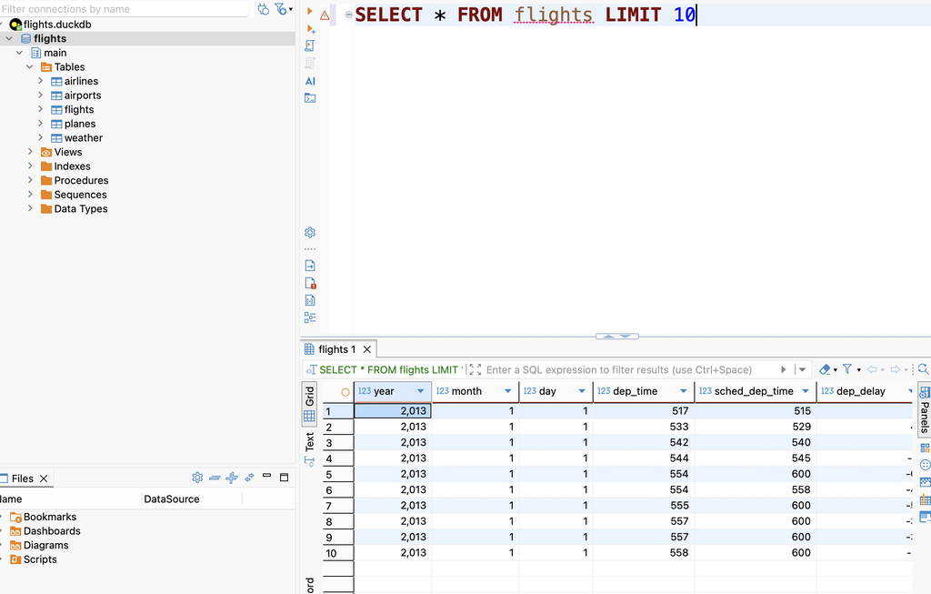

Problem 2a. First 10 rows of the `flights` table using DBeaver.

## 2b - Find the number of flights for each `carrier` in `flights`

This is the same problem as 1b, above, so has the same approach.

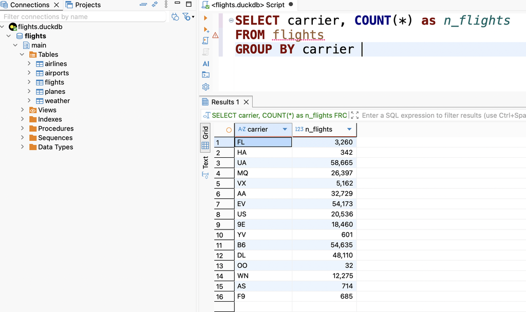

Problem 2b. Number of flights in the `flights` table grouped by `carrier`using DBeaver.

## 2c - Find the average departure delay by `month`

This is similar to problem 1c, except we’re adding complexity by grouping the results by `month`.

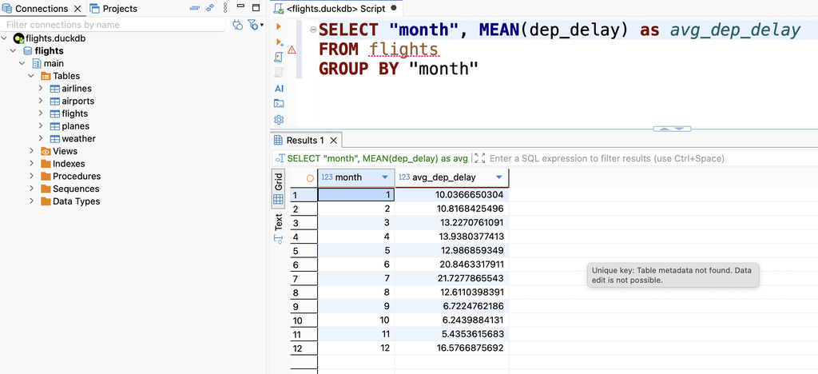

2c. Find the average departure delay by month in the `flights` table.

## 2d - Find the top 10 routes by origin and destination

This problem required three columns to be selected `origin`, `destination` and a new column `n_flights` that counts the number of flights grouped by origin and destination. So, this query results in us being able to find the top 10 busiest routes. I sorted it from high to low to make it easier to interpret.

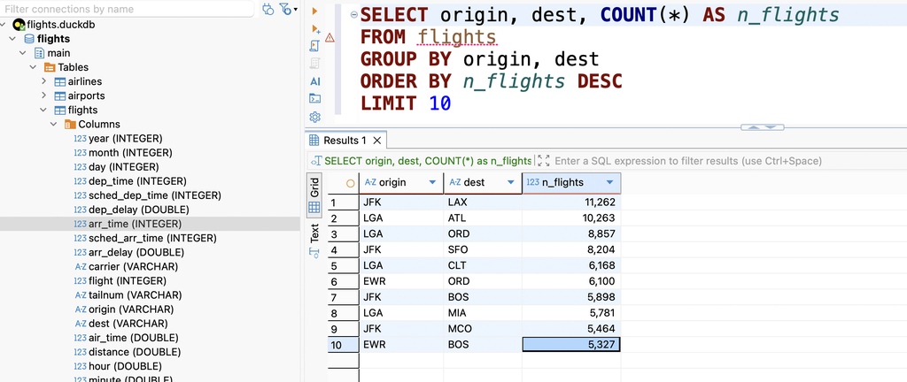

2d. Top 10 routes in the `flights` table grouped by by origin and destination.

## 2e - Export CSV for 2b Query

I followed the instruction to export the file. It is in my GitHub repository and submitted on Canvas.